# Modulo 1 Geostatistica - corso base

Francesco Pirotti

2024-05-31

# Introduzione ad R

# Cosa impareremo

- struttura di R (base e pacchetti), potenzialità
- RStudio: come funziona (panoramica)
- documentazione, esempi, snippets per imparare
- principali categorie di dati: oggetti, variabili e funzioni in R
- assegnazione ed utilizzo variabili
- leggere, rielaborare e scrivere dati strutturati (tabelle) e non
- leggere ed interpretare dati *geo-spaziali*
- rappresentare dati con grafici e mappe

# Materiale

Trovate il materiale in una pagina GitHub [QUI](https://github.com/fpirotti/ARPA2024_corsoBase/)e potrete scaricarlo anche come zip ed anche direttamente nello spazio web [QUI](https://www.cirgeo.unipd.it/archivio/shared/R/ARPA2024_corsoBase/). Troviamo:

- [slides in formato HTML](https://www.cirgeo.unipd.it/archivio/shared/R/ARPA2024_corsoBase/modulo1.html)
- [contenuto slides in formato di documento A4 PDF](https://www.cirgeo.unipd.it/archivio/shared/R/ARPA2024_corsoBase/modulo1.pdf)
- [materiale per gli esercizi](https://www.cirgeo.unipd.it/archivio/shared/R/ARPA2024_corsoBase/dati)

Verrà fornito un link GDrive per caricare gli esercizi per le verifiche.

# R: panoramica

- Ma R serve solo per analisi statistiche? No!
  - E.g. questo materiale è creato con R (vedi *rmarkdown*)
  - Le analisi possono diventare interattive con *Shiny* (esempi progetti InforSAT, VARCITIES…)
  - ….

# R: panoramica

- Installazione di R, versioni
- struttura di R - percorso di installazione

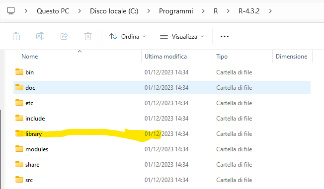

# RStudio

- versione desktop/server
- vantaggi interfaccia:
  - console/terminale/background
  - progetti/packages/help
  - Environment/History/Connection/Tutorial
- Salvare un progetto, cartella di progetto, GIT e GitHub
- Working Directory predefinita, uso del tab per richiamare percorsi

[figure not shown]

# Righe codice - i comandi

R è un programma basato su righe di codice con comandi che eseguono elaborazioni su dati.

L’utente immette i comandi al prompt ( > ) e ciascun comando viene eseguito uno alla volta andando a capo.

Le righe di comando solitamente vengono salvate in un file “script” con estensione “R” (.R) e vengono eseguite una alla volta mediante “invio” o con selezione multipla e “invio”.

Con RStudio è possibile eseguire l’intero file, fermandosi eventualmente in punti specifici “breakpoints” (lo vedremo durante il corso).

> Esercizio: esegui comando della figura alla slide precedente.

```r
saluto <- "ciao"
print(saluto)
```

```
## [1] "ciao"
```

# Commenti e sezioni

NB se inserito all’inizio della riga, e seguito da testo e da 4 o più caratteri `-` o `#`, il testo diventa una sezione

[figure not shown]

# Documentazione/help

Ogni singola funzione ha ampia documentazione con molti esempi. Chiamando una funzione dopo uno o due punti interrogativi richiama la documentazione. Quasi sempre gli esempi sono eseguibili facendo copia/incolla

> Esercizio: esegui il primo esempio dalla documentazione della funzione *print*

```r
?print
??print
```

# Packages/Librerie

Tantissime funzionalità aggiuntive sono disponibili su componenti aggiuntivi che vanno installate con il comando `install.packages(<nome libreria>)` e poi caricate con il comando `library(<nome libreria>)`. Da RStudio possiamo caricarle da interfaccia grafica.

[figure not shown]

# Packages/Librerie

Non tutti sono nella “repository” CRAN, alcuni sono su GitHub o scaricabili da altre fonti - vedi alcune cose sotto

- https://github.com/fpirotti/rPET
- https://github.com/fpirotti/CloudGeometry

```r
# install.packages("devtools")
devtools::install_github("fpirotti/CloudGeometry")
```

# Variabili e funzioni

Qui vediamo una variabile ed una funzione.

**NB1** - la variabile “saluto” è nel Environment (“ambito/ambiente/campo”) *globale**. La funzione “print” è nel campo del package “base” - tieni premuto il tasto CTRL e seleziona il nome della funzione - vedi cosa succede.

**NB2** - operatore di assegnazione `<-` (o `<<-` nel caso si voglia forzare l’assegnazione ad una variabile *globale**)

[figure not shown]

# Variabili e funzioni: Scope

*Le variabili create al di fuori di funzioni sono note come variabili *globali*; possono essere utilizzate sia all’interno delle funzioni che all’esterno.

Sotto andiamo a creare una nostra funzione “salutami” che esegue il saluto. Provate a modificare l’operatore di assegnazione da `<<-` a `<<-` e rieseguire!!

```r
salutami <- function(){
  saluto <- "ciao ARPA!!!"
  print(saluto)
}

print(saluto)
```

```
## [1] "ciao"
```

```r
salutami()
```

```
## [1] "ciao ARPA!!!"
```

```r
print(saluto)
```

```
## [1] "ciao"
```

# Strutture dati in R

NB ogni elemento in R è considerato (ed è) un VETTORE. Le funzioni di R considerano ogni variabile un vettore. Cosa significa? Che le funzioni elaborano tutti gli elementi di un vettore “by default” e che ogni elemento è indicabile con un numero iniziando da 1 (non da 0 come solitamente succede in altri linguaggi).

- vector
- character
- integer
- numeric

```r
miaVar <- FALSE
class(miaVar)
miaVar[[1]]
miaVar[[2]]
```

# Tipo dati: vettori

Perchè succede quello che vedete sotto (dati *numeric* diventano *character*)?

```r
miaVar <- c(1,4,6,8)
class(miaVar)
```

```
## [1] "numeric"
```

```r
miaVar[[1]]
```

```
## [1] 1
```

```r
miaVar[[2]]
```

```
## [1] 4
```

```r
miaVar[[2]] <- "evviva"
class(miaVar)
```

```
## [1] "character"
```

```r
print(miaVar)
```

```
## [1] "1"      "evviva" "6"      "8"
```

# Tipo dati: matrix

Matrix è un oggetto con struttura di matrice ovvero bidimensionale (righe × colonne); pensate a un gruppo di vettori impilati o affiancati.

Si accede e si assegnano i valori con [r,c] dove r e ci sono gli indici di riga e colonna. Si può lasciare vuoto un indice per accedere alla riga/colonna

```r
mat <- matrix(c(1, 2, 3, 4), nrow = 2, ncol = 2)
mat[[2]]
```

```
## [1] 2
```

```r
mat[1,2]
```

```
## [1] 3
```

```r
mat[1,]
```

```
## [1] 1 3
```

```r
mat[1,2] <- 100
```

# Tipo dati: array

Un array è una matrice multidimensionale.

r=rows, c=columns, m=matrice…. etc…

> Esercizio: vedi sotto come creare un array a 3 dimensioni. Nota che duplica 9 valori 2 volte. Prova a dare 8 valori invece che nove. Prova a dare 3 valori. Cosa succede.

```r
# 2 vettori di valori
valori1 <- c(5, 9, 3)
valori2 <- c(10, 11, 12, 13, 14, 15)
column.names <- c("C1", "C2", "C3")
row.names <- c("R1", "R2", "R3")
matrix.names <- c("Matrix1", "Matrix2")

# Crea un array a tre dimensioni
arr <- array(c(valori1, valori2), dim = c(3, 3, 2),
                  dimnames = list(row.names,
                                  column.names,
                                  matrix.names))
print(arr)
```

```
## , , Matrix1
##
##    C1 C2 C3
## R1  5 10 13
## R2  9 11 14
## R3  3 12 15
##
## , , Matrix2
##
##    C1 C2 C3
## R1  5 10 13
## R2  9 11 14
## R3  3 12 15
```

# Tipo dati: List

Le strutture vector/matrix/array, possono contenere solo una tipologia base (numeric, integer, character, logical…). Ma la struttura LIST no!

La struttura *list* è un set di dati eterogenei; opzionalmente, è possibile assegnare dei nomi a ciascun elemento nel set.

```r
lista <- list(1,4,6,8)
class(lista)
```

```
## [1] "list"
```

```r
lista[[1]]
```

```
## [1] 1
```

```r
lista[[2]]
```

```
## [1] 4
```

```r
lista[[2]] <- "evviva"
class(lista)
```

```
## [1] "list"
```

```r
lista[[1]]
```

```
## [1] 1
```

```r
lista[[2]]
```

```
## [1] "evviva"
```

```r
print(lista)
```

```
## [[1]]
## [1] 1
##
## [[2]]
## [1] "evviva"
##
## [[3]]
## [1] 6
##
## [[4]]
## [1] 8
```

# Tipo dati: List c/nomi

NB, la struttura LIST non è altro che un set, una “lista”, di oggetti associata ad un indice. L’indice è un numero intero ma può essere un testo (simile al concetto di coppie “key->value”/chiave->valore).

Può essere assegnato un indice/chiave per riferimento all’elemento nella lista

```r
names(lista)
```

```r
names(lista) <- c("primo", "secondo")
lista[[1]]
```

```
## [1] 1
```

```r
lista[["primo"]]
```

```
## [1] 1
```

Svantaggi di strutture tipo *list*: usa più memoria!

> **Nota su allocazione memoria**: se dovete gestire volumi importanti di dati, considerate la pre-allocazione della memoria SE conoscete la dimensione. Vedi anche blog [qui](https://blog.sellorm.com/2019/12/16/vector-pre-allocation-in-r-a-simple-example/).

```r
vettoreMoltoGrande = numeric(1000)
vettoreMoltoGrande[[100]]
```

```
## [1] 0
```

# Tipo dati: Data frame

Un *data frame* è una struttura di tipo *list* ma con un numero uguale di “righe” per ogni colonna di attributi. È possibile manipolare i data frame filtrando sulle righe e operando sulle colonne.

Sia righe che colonne possono avere identificativi.

```r
 c.lat <- c(45.1, 45.2, 45.3)
 c.lon <- c(11.1, 11.2, 11.3)

 df.geo.stz <- data.frame(stz=c("A", "B","C"),
                          longitudine=c.lon,
                          latitudine=c.lat)

 colnames(df.geo.stz)
```

```
## [1] "stz"         "longitudine" "latitudine"
```

```r
 rownames(df.geo.stz)
```

```
## [1] "1" "2" "3"
```

```r
 rownames(df.geo.stz) <- df.geo.stz$stz
 rownames(df.geo.stz)
```

```
## [1] "A" "B" "C"
```

# Tipo dati: Data frame

Le colonne sono *vettori* - si può richiamare e assegnare i valori di una colonna con `$` o `[[]]` o `[,"<nomecolonna>"]` o `[ riga,"<nomecolonna>"]`

Come con Tipo dati: matrix si possono usare gli indici di riga/colonna.

```r
df.geo.stz$stz
df.geo.stz[,"stz"]
df.geo.stz[["stz"]]
df.geo.stz$stz <- c("A1","B1", "C1")
```

# Tipo dati: Tibble

Un data frame particolare, lo vedremo quando usiamo l’infrastruttura di librerie “tidyverse”. Vantaggi:

- Non modifica il nome mettendo un punto al posto degli spazi (Vedi esempio)
- Non utilizza mai `row.names()`. Lo scopo di *tidyverse* è quello di memorizzare le variabili in modo coerente. Quindi non memorizza mai una variabile come attributo speciale (i.e. nomi riga).

```r
library(tidyverse)
geo.stz.tb <- tibble(df.geo.stz)
class(geo.stz.tb)
```

```
## [1] "tbl_df"     "tbl"        "data.frame"
```

```r
#geo.stz.tb
names(data.frame(`nome colonna con spazi` = 1))
```

```
## [1] "nome.colonna.con.spazi"
```

```r
names(tibble(`nome colonna con spazi` = 1))
```

```
## [1] "nome colonna con spazi"
```

- Ricicla solo vettori di lunghezza 1. Questo perché il riciclo di vettori di lunghezza superiore è una fonte frequente di problemi nascosti. Riciclo: prova i seguenti comandi:

```r
v <- 1:10
v[]
```

```
##  [1]  1  2  3  4  5  6  7  8  9 10
```

```r
v[] <- 1
v[]
```

```
##  [1] 1 1 1 1 1 1 1 1 1 1
```

```r
v[] <- 1:5
v[]
```

```
##  [1] 1 2 3 4 5 1 2 3 4 5
```

```r
# sotto non funziona!
#v[] <- 1:3
```

# Convertire oggetti

Oggetti tra loro compatibili si possono convertire; ad esempio tra matrix => data.frame usando il comando `as.data.frame(<oggetto matrix>)` viceversa attenzione che tutti i tipi di vettore vengono resi omogenei.

Provate il seguente esercizio sotto.

```r
mat
```

```
##      [,1] [,2]
## [1,]    1  100
## [2,]    2    4
```

```r
df.mat <- as.data.frame(mat)
as.matrix(df.mat)
```

```
##      V1  V2
## [1,]  1 100
## [2,]  2   4
```

```r
df.mat$nuovaColonna <- "testo"
as.matrix(df.mat)
```

```
##      V1  V2    nuovaColonna
## [1,] "1" "100" "testo"
## [2,] "2" "  4" "testo"
```

```r
df.mat
```

```
##   V1  V2 nuovaColonna
## 1  1 100        testo
## 2  2   4        testo
```

# Salvare oggetti R

Rstudio può salvare l’intero progetto con le variabili e le funzioni che vedete in alto a destra.

Il comando `save` salva in un file con estensione “rda” che viene riconosciuto anche direttamente da RStudio. NB è possibile salvare qualiasi oggetto, anche funzioni!

Prova a cliccare sul file dopo aver lanciato la prima riga del comando seguente!

```r
## NB salvo anche la funzione "salutami" fatta all'inizio!
save(df.geo.stz, salutami, file="oggetti.rda")
load("oggetti.rda")
saveRDS(df.geo.stz, file = "geo.stz.RDS")
df.geo.stz <- readRDS("geo.stz.RDS")
```

# Operatori di R

Gli operatori aritmetici e logici di R funzionano sia su singoli scalari che su vettori e strutture come *array* e *matrix*.

NB questo vuol dire che si possono eseguire operazioni su tutti i singoli valori della struttura internamente (*vectorization*)!

```r
c.lat + 10
c.lat == c.lon

c.lat[[1]] <- 44
c.lat <- c.lat - 1
## AND / OR
c.lat == c.lon & c.lat==0
c.lat == c.lon | c.lat==45.1
df.mat$V3 <- df.mat$V2**2
#c.lat == c.lon && c.lat==c.lat
#c.lat == c.lon || c.lat==c.lat
```

# Esercizio 1

- Creare una funzione chiamata *crea.df* che esegue la seguente operazione:
  - creazione di un oggetto data.frame con 2 colonne, (Stazione, ValoreX) e 4 righe. Inventate voi i valori. Calcolo una terza colonna con il quadrato di ValoreX.
- Eseguire la funzione per creare un oggetto di tipo “tibble” chiamato *tabella.tb*
- **Consegnate** un file RDA contenente i due oggetti, la funzione *crea.df* e il tibble *tabella.tb -* chiamate il file con: es1_cognome_nome.rda, e.g. *es1_pirotti_francesco.rda*

# Data in/process/out

# Cosa faremo

Impareremo a leggere/trasformare/scrivere dati da fonti diverse:

- file di testo strutturati (**CSV**)
- fogli di lavoro (**XLSX**)
- dati online non strutturati come **JSON**

# Input dati: CSV

I file CSV sono notoriamente file di testo strutturati come tabelle e molto utilizzati per condividere dati.

Il comando standard è `read.csv` .

NB non è ottimizzato per l’efficienza. Per dati massivi usare il comando `fread` dalla libreria data.table `data.table::fread()`.

Facciamo un esercizio con dati ARPA! Scarichiamo dalla pagina [QUI](https://www.arpa.veneto.it/arpavinforma/indicatori-ambientali/indicatori_ambientali/clima-e-rischi-naturali/immagini-e-file-allegati/2021/prec_mensili_2020.csv) o direttamente da [QUI](https://www.arpa.veneto.it/arpavinforma/indicatori-ambientali/indicatori_ambientali/clima-e-rischi-naturali/immagini-e-file-allegati/2021/prec_mensili_2020.csv/@@download/file) i dati di precipitazione mensile - salvateli in una sottocartella “dati” e caricateli usando sia la funzione read.csv che fread dalla libreria data.table (se l’avete altrimenti vedete a schermo i risultati). Si vuole notare le differenze e come si chiama una funzione SENZA caricare una libreria, usando `::`.

```r
prec <- read.csv("dati/Prec_mensili_2020.csv")
prec2 <- data.table::fread("dati/Prec_mensili_2020.csv")
summary(prec2)
```

```
##  Precipitazioni mensili Veneto   2020 (mm)      media 1993-2019 (mm)
##  Length:13                     Min.   :   7.0   Min.   :  57.0
##  Class :character              1st Qu.:  28.0   1st Qu.:  74.0
##  Mode  :character              Median :  89.0   Median :  96.0
##                                Mean   : 180.2   Mean   : 171.5
##                                3rd Qu.: 171.0   3rd Qu.: 114.0
##                                Max.   :1171.0   Max.   :1114.0
```

> Esercizio: Importate i dati inserendo i parametri corretti di read.csv - come noterete, la prima riga NON importa correttamente. La seconda si, ma è una funzione della libreria data.table. Usate la documentazione in R per capire come aggiungere argomenti alla funzione read.csv (vedi sezione QUI). **NB** usate il tasto TAB per richiamare i percorsi, risparmiate tempo e fatica!

# Input dati: Fogli excel

I fogli di calcolo in formato MS Excel sono più strutturati rispetto ad un file CSV, dato che ogni colonna ha anche lo specifico tipo di dati (numero, testo, data ecc…).

Per leggere/scrivere questi dati è necessario usare librerie aggiuntive.

```r
prec3 <- prec2
## nuova colonna
prec3$norm2020 <- prec3$`2020 (mm)` / prec3$`media 1993-2019 (mm)`
writexl::write_xlsx( list("originale" =prec2, "elaborata"=prec3), path="dati/output.xlsx" )
prec4 <- readxl::read_xlsx("dati/output.xlsx")
```

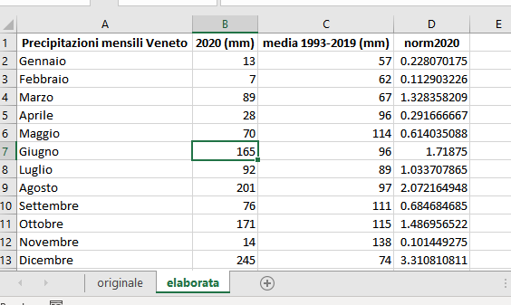

# Grafici di base

La funzione `plot` riesce a creare grafici di base. Andiamo a confrontare le precipitazioni del 2020 con quelle medie 1993-2019.

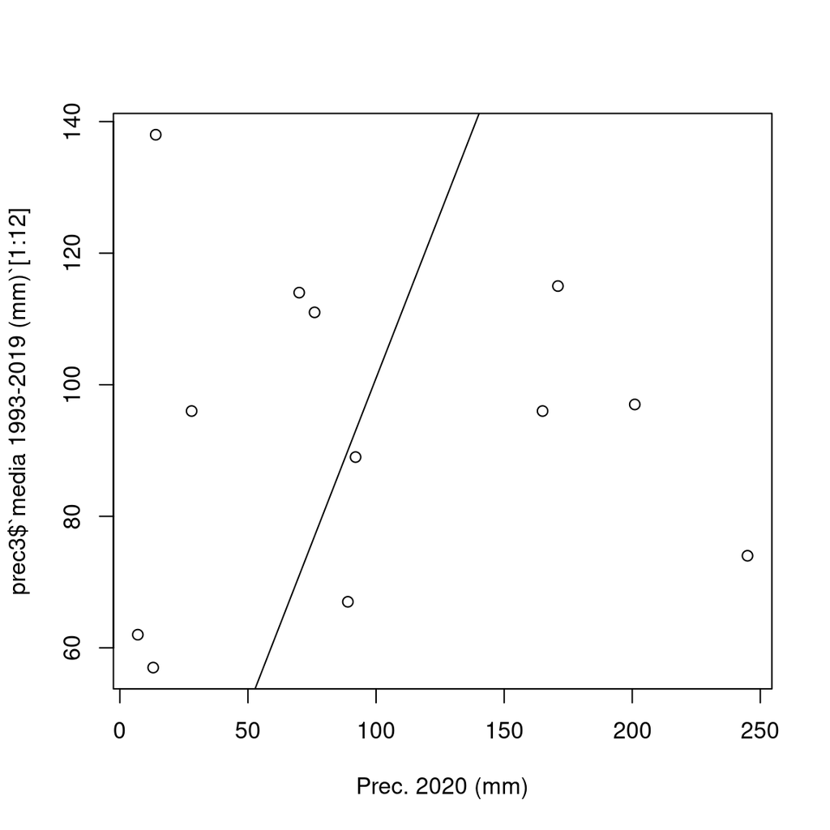

```r
plot(prec3$`2020 (mm)`[1:12], prec3$`media 1993-2019 (mm)`[1:12], xlab="Prec. 2020 (mm)")
abline(1,1)
```

# Grafici di base

Miglioriamo un po’ il grafico - ma utilizzeremo poi la libreria ggplot2 per ottenere grafici migliori.

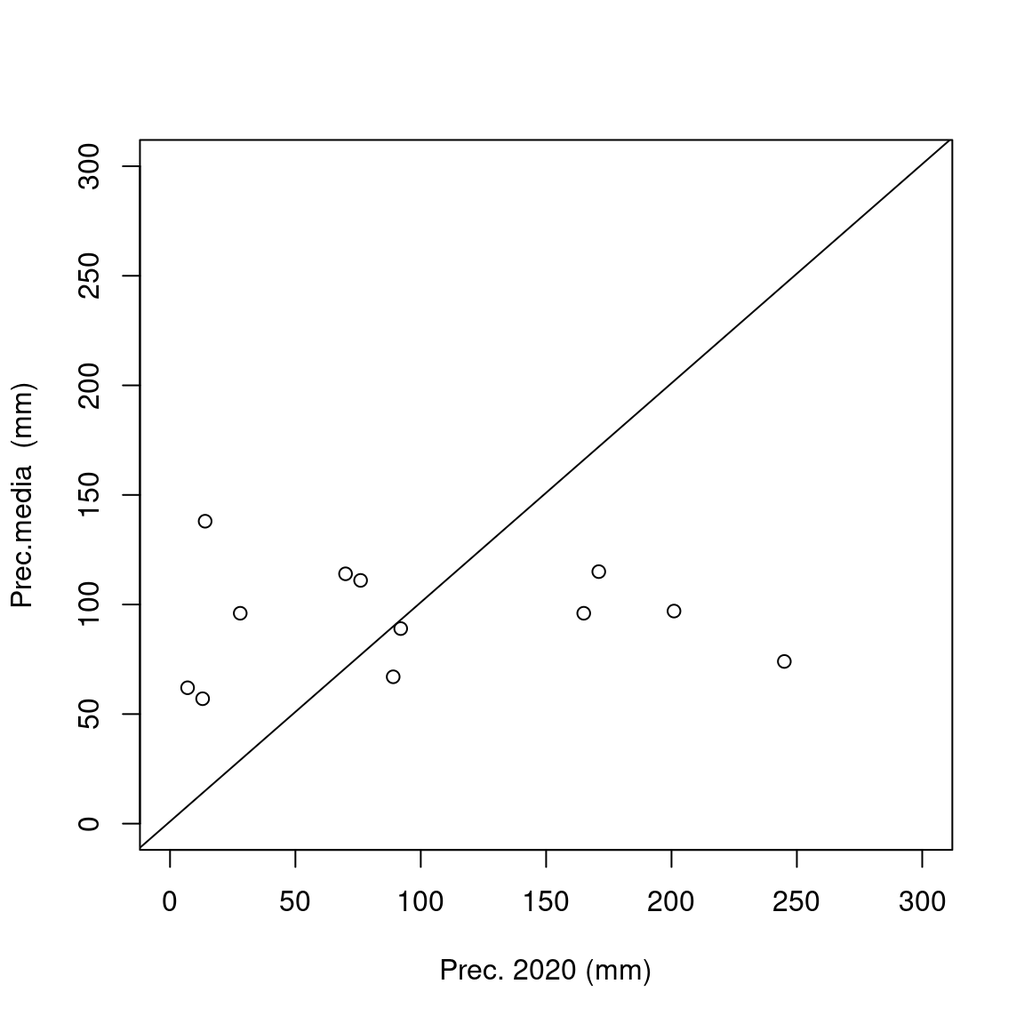

```r
plot(prec3$`2020 (mm)`[1:12], prec3$`media 1993-2019 (mm)`[1:12],
     xlab="Prec. 2020 (mm)", ylab="Prec.media  (mm)",
     xlim=c(0,300), ylim=c(0,300))
abline(1,1)
```

# Input dati: JSON

I dati JSON (**J**ava**S**cript **O**bject **N**otation) sono molto utilizzati per trasferire dati non strutturati. Vedi [QUI](https://developer.mozilla.org/en-US/docs/Learn/JavaScript/Objects/JSON) e [QUI](https://www.freecodecamp.org/news/what-is-json-a-json-file-example/). Anche per dati “geo” con il GeoJSON (vedi esempio [QUI](https://it.wikipedia.org/wiki/GeoJSON)).

Usiamo direttamente da API ARPAV “Anagrafica stazioni in formato JSON” dalla [pagina QUI](https://www.arpa.veneto.it/dati-ambientali/dati-in-diretta/meteo-idro-nivo/variabili_meteo)

```r
## Scarichiamo direttamente da API ARPAV
api.url <- "https://api.arpa.veneto.it/REST/v1/meteo_meteogrammi?rete=MGRAMMI&coordcd=18&orario=0&rnd=0.9966091913301682"
stazioni.meteo <- jsonlite::read_json(api.url)
```

# Trasformazione dei dati

# Introduzione

Modificare dati significa aggiungere, togliere, filtrare, manipolare colonne, creare sommari e statistiche di interesse aggreando dati. Insomma il dato viene “manipolato”. In inglese viene anche usato “data wrangling”

Ci “alleniamo” con i dati JSON delle stazioni meteo ARPAV scaricati dal JSON.

**Obiettivo**: creare un grafico con la posizione delle stazioni e aggiungere qualche valore mediante unione con altri dati.

# Iteratori

Fondamentale saper utilizzare operazioni che eseguono su tutti gli elementi di un oggetto. E.g. tutte le colonne di un *data.frame*, tutte le righe di un *data.frame*, tutti gli oggetti di una *list*…

```r
dati <- stazioni.meteo$data
length(dati)
## LOOP classico: visto male per
## performance bassa,
## ma non necessariamente vero
for(i in 1:length(dati)){
  print(dati[[i]])
  break / next
}

funz <- function(x){
  length(x)
}
# lapply/mapply/sapply/apply per righe/colonne
# lapply(dati, funz)
```

# Iteratori tidy

L’operatore “map” è simile agli “apply” ma con più funzionalità. Vedi sotto, usando *map_df* i risultati vengono raccolti su una tabella (tibble)!

```r
library(tidyverse)
## i dati sono strutturati nell'oggetto "data"
##  come liste dentro altre liste
# as.data.frame(stazioni.meteo$data)
dt <- map(.x = stazioni.meteo$data, .f = function(x){ x } )
dtf <- map_df (.x = stazioni.meteo$data, .f = function(x){ x } )
```

# Convertire tipologie di colonne

Mappando a data.frame con `map` abbiamo solo colonne di tipo character… come mai?* NB con `map_df` questo non succede perchè la funzione `map_df` è “smart” e capisce qualche tipo usare per ogni colonna. TRANNE che per la colonna valore. Perchè?**

NB gli iteratori su tabelle (data.frame o tibble) lavorano per colonne.

```r
## richiamo la classe di ogni colonna
# map(.x = dt, .f = function(x){ class(x) } )
map(.x = dtf, .f = function(x){ class(x) } )
## ATTENZIONE - colonna valore è corretta?
dtf$valore <- as.numeric(dtf$valore)
dtf$tipo <- as.factor(dtf$tipo)
levels(dtf$tipo)
```

*Perchè raccoglie ogni elemento della lista in un vettore ed il vettore può avere solo valori di un tipo base (*character, numeric, integer, logical…*) - sceglie sempre il *character* se valori misti

** Nota che nel JSON il numero in “valore” è tra virgolette, dunque viene visto come testo (character) e non come numerico. Confronta con latitudine e longitudine!